# STAT 353: Homework 3

Zeqiu.Yu

Feb. 23, 2022

## Handwork

*My policy on handwork is that it is required for Statistics PhD students and MS in Statistics students. It is encouraged (but not required) for MS in Applied Statistics and all other students. (If you are the latter, you will not get penalized if you get these wrong … )*

Exercises from the book: 20.5, 20.10, 20.13, 21.4, 22.2

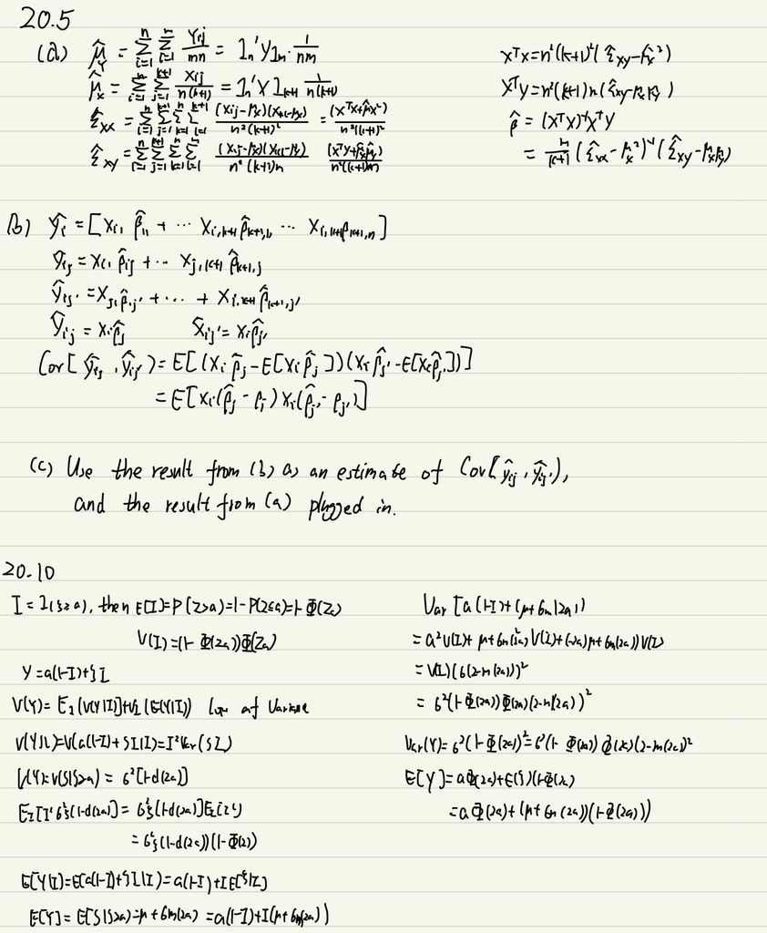

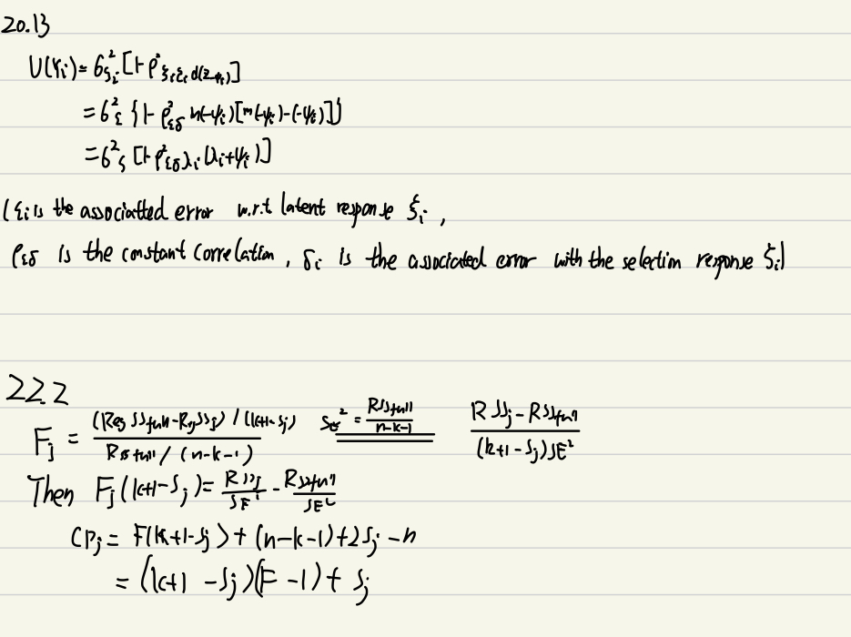

```r
# Load the packages
library(boot)
library(car)
library(tidyverse)
library(sampleSelection)
library(caret)
library(mice)
library(censReg)
```

### 21.4

```r
set.seed(353)
n <- 10
y <- rnorm(n, mean = 0, sd = 10)
y_bar <- mean(y)
 #sample variance
sample_var <- sum((y - y_bar)^2)/n

#define a function to calculate the variance of a bootstrap sample
bootstrap_var <- function(data, index){
X <- data[index] # Get the boostrap sample
x_bar <- mean(X)
sum((X - x_bar)^2)/(n - 1) # Bootstrap variance
}

# Perform bootstrap to estimate variance
bootstrap_results <- boot(data = y, statistic = bootstrap_var, R = 500)
bootstrap_estimate <- bootstrap_results$t0
# Calculate bias in variance estimate
bias_estimate <- bootstrap_estimate - sample_var
bias_estimate
```

```
## [1] 6.038375
```

Based on the bootstrap analysis, it appears that the estimated bias is 6.0383751, which is significantly different from the theoretical value of -10. However, considering the small size of the sample, such a deviation is not surprising. As the number of replications is increased, the estimated bias is expected to approach the theoretical value, indicating that the initial difference is likely due to chance fluctuations.

You can type your answers and submit within this file *or* you can do this work on paper and submit a scanned copy (be sure it is legible).

## Data analysis

### **1. Exercise D20.1 (MI)**

Using the United Nations social-indicators data (in `UnitedNations.txt`), develop a regression model for the response variable female expectation of life. Feel free to use whatever explanatory variables in the data set make sense to you, and to employ variable transformations, methods of fitting the model other than least-squares regression (e.g., nonparametric), etc.

1. Work initially with complete cases, and once you have an apparently satisfactory model,obtain estimates and standard errors of the regression coefficients.

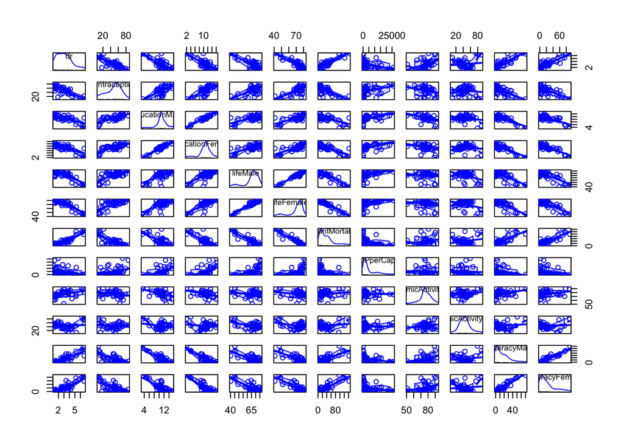

```r
UN <- read.table("Datasets/UnitedNations.txt")
UN <- UN[complete.cases(UN), ]

# EDA
scatterplotMatrix(UN[,-1])
```

```r
# From the plot above GDP appears to need a log transformation
model11 <- lm(lifeFemale~. -GDPperCapita-lifeMale+log(GDPperCapita), data=UN)
# Check LR test for significant variables
Anova(model11)
```

```
## Anova Table (Type II tests)
##
## Response: lifeFemale
##                         Sum Sq Df F value  Pr(>F)
## region                  90.025  4  2.9400 0.04131 *
## tfr                     34.773  1  4.5425 0.04351 *
## contraception           10.975  1  1.4337 0.24286
## educationMale           14.056  1  1.8362 0.18802
## educationFemale          6.056  1  0.7911 0.38258
## infantMortality         39.391  1  5.1457 0.03258 *
## economicActivityMale     7.785  1  1.0169 0.32331
## economicActivityFemale  40.114  1  5.2401 0.03117 *
## illiteracyMale          17.053  1  2.2277 0.14859
## illiteracyFemale         5.303  1  0.6927 0.41344
## log(GDPperCapita)        3.943  1  0.5151 0.47987
## Residuals              183.722 24
## ---
## Signif. codes:  0 '***' 0.001 '**' 0.01 '*' 0.05 '.' 0.1 ' ' 1
```

```r
# Based on the P-value we have our Refined model
model12 <- lm(lifeFemale~region+tfr+infantMortality+economicActivityFemale, data=UN)
S(model12)
```

```
## Call: lm(formula = lifeFemale ~ region + tfr + infantMortality +
##          economicActivityFemale, data = UN)
##
## Coefficients:
##                        Estimate Std. Error t value Pr(>|t|)
## (Intercept)            81.66380    2.84965  28.657  < 2e-16 ***
## regionAmerica           5.44878    1.63874   3.325  0.00228 **
## regionAsia              4.64940    1.63673   2.841  0.00788 **
## regionEurope            2.91595    2.23392   1.305  0.20139
## regionOceania           8.31981    2.91870   2.851  0.00769 **
## tfr                    -1.44277    0.80780  -1.786  0.08388 .
## infantMortality        -0.17175    0.03331  -5.155 1.38e-05 ***
## economicActivityFemale -0.08556    0.02738  -3.125  0.00384 **
## ---
## Signif. codes:  0 '***' 0.001 '**' 0.01 '*' 0.05 '.' 0.1 ' ' 1
##
## Residual standard deviation: 2.714 on 31 degrees of freedom
## Multiple R-squared: 0.9399
## F-statistic: 69.28 on 7 and 31 DF,  p-value: < 2.2e-16
##    AIC    BIC
## 197.59 212.57
```

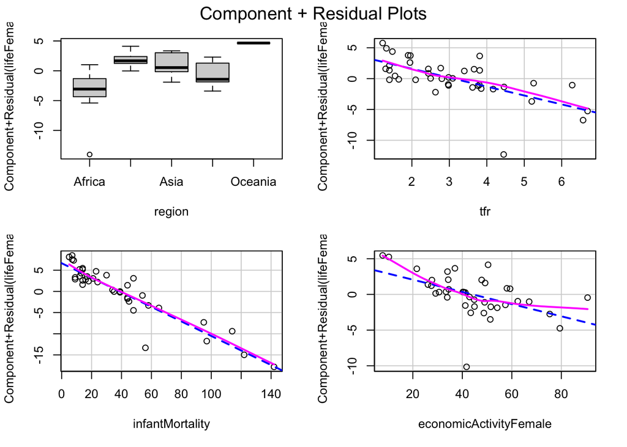

```r
crPlots(model12)
```

```r
outlierTest(model12)
```

```
##           rstudent unadjusted p-value Bonferroni p
## Botswana -6.152154         9.1196e-07   3.4655e-05
```

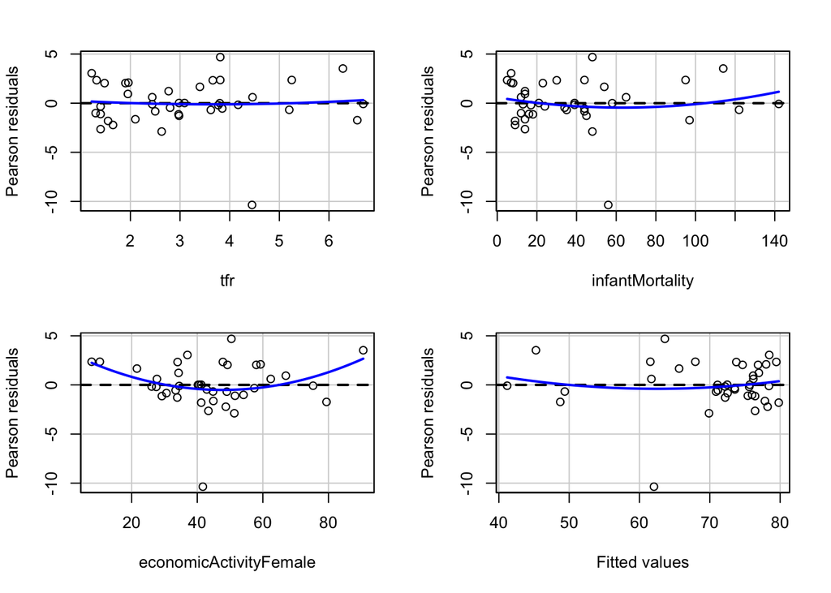

```
##                        Test stat Pr(>|Test stat|)
## tfr                       0.4752          0.63806
## infantMortality           0.9613          0.34406
## economicActivityFemale    2.5902          0.01466 *
## Tukey test                0.7270          0.46720
## ---
## Signif. codes:  0 '***' 0.001 '**' 0.01 '*' 0.05 '.' 0.1 ' ' 1
```

```r
residualPlots(model12)
```

2. Now redo your analysis in (a) but use multiple imputation.

```r
UN <- read.table("Datasets/UnitedNations.txt", header = TRUE)
m <- 5
seed <- 353
# Perform multiple imputations using "mice"
UN_imputed <- mice(UN, m = m, seed = seed, maxit=20, printFlage=FALSE)
models <- with(UN_imputed, {
  lm(lifeFemale ~ region + tfr + contraception + educationMale +
     educationFemale + infantMortality + log(GDPperCapita) +
     economicActivityMale + economicActivityFemale +
     illiteracyMale + illiteracyFemale)
})

pooled_model <- pool(models)
summary(pooled_model)
```

```
##                      term     estimate  std.error  statistic         df
## 1             (Intercept) 67.966969805 3.63301179 18.7081611  73.071084
## 2           regionAmerica  3.509105611 0.79750043  4.4001301 184.942155
## 3              regionAsia  3.326342551 0.66275266  5.0189803 170.460545
## 4            regionEurope  2.843510397 0.89881497  3.1636216 124.721813
## 5           regionOceania  2.110308013 0.95242511  2.2157207 173.893145
## 6                     tfr -1.173289542 0.28674862 -4.0917007  41.046706
## 7           contraception  0.003569418 0.01870501  0.1908269  29.465281
## 8           educationMale  0.512138860 0.74100531  0.6911406   4.794575
## 9         educationFemale -0.315272436 0.71388931 -0.4416265   4.606052
## 10        infantMortality -0.181941127 0.02066665 -8.8036116   9.379438
## 11      log(GDPperCapita)  0.513439648 0.24071804  2.1329504  25.701619
## 12   economicActivityMale  0.077091102 0.03762274  2.0490560 127.049344
## 13 economicActivityFemale -0.037004286 0.02106531 -1.7566461  11.220045
## 14         illiteracyMale  0.070156198 0.04967460  1.4123153  58.137751
```

[output cut: 17 more lines]

```r
## refine the model
refined_imputed_models <- with(UN_imputed, {
  lm(lifeFemale~region+tfr+infantMortality+economicActivityFemale)
})

refined_pooled_models <- pool(refined_imputed_models)
summary(refined_pooled_models)
```

```
##                     term    estimate  std.error  statistic        df
## 1            (Intercept) 80.19507004 1.32216885  60.654182  95.12416
## 2          regionAmerica  4.00557171 0.79969951   5.008846 156.06063
## 3             regionAsia  3.53679356 0.68094707   5.193933 160.60328
## 4           regionEurope  3.29481658 0.91312553   3.608284 144.67114
## 5          regionOceania  2.59894922 0.97273278   2.671802 166.03696
## 6                    tfr -1.13692506 0.23182957  -4.904142 181.26935
## 7        infantMortality -0.20034990 0.01039445 -19.274692 162.55067
## 8 economicActivityFemale -0.03329483 0.01547358  -2.151721  31.77738
##        p.value
## 1 7.731709e-78
## 2 1.466487e-06
## 3 6.164003e-07
## 4 4.238303e-04
## 5 8.296216e-03
## 6 2.077541e-06
## 7 7.694921e-44
## 8 3.912388e-02
```

3. Compare these results to those from the complete-case analysis. What do you conclude?

```r
summary(model12)
```

```
##
## Call:
## lm(formula = lifeFemale ~ region + tfr + infantMortality + economicActivityFemale,
##     data = UN)
##
## Residuals:
##      Min       1Q   Median       3Q      Max
## -10.3575  -1.0597  -0.1075   1.8518   4.6895
##
## Coefficients:
##                        Estimate Std. Error t value Pr(>|t|)
## (Intercept)            81.66380    2.84965  28.657  < 2e-16 ***
## regionAmerica           5.44878    1.63874   3.325  0.00228 **
## regionAsia              4.64940    1.63673   2.841  0.00788 **
## regionEurope            2.91595    2.23392   1.305  0.20139
## regionOceania           8.31981    2.91870   2.851  0.00769 **
## tfr                    -1.44277    0.80780  -1.786  0.08388 .
## infantMortality        -0.17175    0.03331  -5.155 1.38e-05 ***
## economicActivityFemale -0.08556    0.02738  -3.125  0.00384 **
## ---
## Signif. codes:  0 '***' 0.001 '**' 0.01 '*' 0.05 '.' 0.1 ' ' 1
##
## Residual standard error: 2.714 on 31 degrees of freedom
## Multiple R-squared:  0.9399, Adjusted R-squared:  0.9264
## F-statistic: 69.28 on 7 and 31 DF,  p-value: < 2.2e-16
```

```r
summary(refined_pooled_models)
```

```
##                     term    estimate  std.error  statistic        df
## 1            (Intercept) 80.19507004 1.32216885  60.654182  95.12416
## 2          regionAmerica  4.00557171 0.79969951   5.008846 156.06063
## 3             regionAsia  3.53679356 0.68094707   5.193933 160.60328
## 4           regionEurope  3.29481658 0.91312553   3.608284 144.67114
## 5          regionOceania  2.59894922 0.97273278   2.671802 166.03696
## 6                    tfr -1.13692506 0.23182957  -4.904142 181.26935
## 7        infantMortality -0.20034990 0.01039445 -19.274692 162.55067
## 8 economicActivityFemale -0.03329483 0.01547358  -2.151721  31.77738
##        p.value
## 1 7.731709e-78
## 2 1.466487e-06
## 3 6.164003e-07
## 4 4.238303e-04
## 5 8.296216e-03
## 6 2.077541e-06
## 7 7.694921e-44
## 8 3.912388e-02
```

Based on the summary results of the two models, we can observe that the estimates obtained from the complete case model are comparable to those of the multiple imputation model, but the former has larger standard errors. Additionally, all variables in the multiple imputation model are statistically significant, while tfr in the complete case model is not statistically significant. It is important to note that the complete case model has a smaller sample size, whereas the multiple imputation model utilizes all available data and accounts for uncertainty in the imputed values, increasing precision. Therefore, based on these findings, the multiple imputation model is preferred over the complete case model, as it can provide more accurate and unbiased estimates.

### **2. Exercise D20.3 (Selection)**

Long (1997) reports a regression in which the response variable is the prestige of the academic departments where PhDs in biochemistry find their first jobs. The data are in the file `Long-PhDs.txt`.

Prestige is measured on a scale that runs from 1.00 to 5.00, and is unavailable for departments without graduate programs and for departments with ratings below 1.00. The explanatory variables include a dummy regressor for gender; the prestige of the department in which the individual obtained his or her PhD; the number of citations received by the individualís mentor; a dummy regressor coding whether or not the individual held a fellowship; the number of articles published by the individual; and the number of citations received by the individual.

Estimate the regression of prestige of first job on the other variables in three ways:

1. code all of the missing values as 1.00 and perform an OLS regression;

```r
phd <- read.table("Datasets/Long-PhDs.txt", header = TRUE)

phd_ols <- phd
# Replace missing values in the "job" column with 1
phd_ols$job[is.na(phd_ols$job)] <- 1.00

model21 <- lm(job ~ gender + phd + mentor + fellowship + articles + citations, data = phd_ols)
# Display the summary of the OLS model
summary(phd_ols)
```

```
##       job           gender               phd            mentor
##  Min.   :1.000   Length:408         Min.   :1.000   Min.   :  0.00
##  1st Qu.:1.200   Class :character   1st Qu.:2.482   1st Qu.:  4.00
##  Median :2.180   Mode  :character   Median :3.360   Median : 19.00
##  Mean   :2.233                      Mean   :3.201   Mean   : 45.47
##  3rd Qu.:3.040                      3rd Qu.:4.000   3rd Qu.: 56.25
##  Max.   :4.800                      Max.   :4.800   Max.   :532.00
##   fellowship           articles        citations
##  Length:408         Min.   : 0.000   Min.   :  0.00
##  Class :character   1st Qu.: 1.000   1st Qu.:  0.00
##  Mode  :character   Median : 2.000   Median :  8.00
##                     Mean   : 2.277   Mean   : 21.72
##                     3rd Qu.: 3.000   3rd Qu.: 29.25
##                     Max.   :18.000   Max.   :203.00
```

```r
model21_reduced = lm(job ~ phd + fellowship + citations, data = phd_ols)
anova(model21_reduced, model21)
```

```
## Analysis of Variance Table
##
## Model 1: job ~ phd + fellowship + citations
## Model 2: job ~ gender + phd + mentor + fellowship + articles + citations
##   Res.Df    RSS Df Sum of Sq      F  Pr(>F)
## 1    404 309.61
## 2    401 304.74  3    4.8711 2.1366 0.09506 .
## ---
## Signif. codes:  0 '***' 0.001 '**' 0.01 '*' 0.05 '.' 0.1 ' ' 1
```

The p-value is larger than 0.05, we don’t reject the null hypothesis.

```r
model22 <- model21_reduced
summary(model21_reduced)
```

```
##
## Call:
## lm(formula = job ~ phd + fellowship + citations, data = phd_ols)
##
## Residuals:
##      Min       1Q   Median       3Q      Max
## -1.95931 -0.68062 -0.01696  0.70039  2.16331
##
## Coefficients:
##               Estimate Std. Error t value Pr(>|t|)
## (Intercept)   0.995802   0.154611   6.441 3.38e-10 ***
## phd           0.298556   0.047242   6.320 6.93e-10 ***
## fellowshipyes 0.249073   0.094305   2.641  0.00858 **
## citations     0.005906   0.001396   4.231 2.88e-05 ***
## ---
## Signif. codes:  0 '***' 0.001 '**' 0.01 '*' 0.05 '.' 0.1 ' ' 1
##
## Residual standard error: 0.8754 on 404 degrees of freedom
## Multiple R-squared:  0.1975, Adjusted R-squared:  0.1915
## F-statistic: 33.14 on 3 and 404 DF,  p-value: < 2.2e-16
```

2. treat the missing values as truncated at 1.00 and employ Heckmanís selection-regression model;

```r
phd_heck <- phd
phd_heck <- mutate(phd_heck, lfp = if_else(job > 1, "1", "0"))
phd_heck$lfp[is.na(phd_heck$lfp)] <-  0
model23 <- selection(lfp ~ phd + fellowship + citations,
                              job ~ phd + fellowship + citations, data = phd_heck)
summary(model23)
```

```
## --------------------------------------------
## Tobit 2 model (sample selection model)
## Maximum Likelihood estimation
## Newton-Raphson maximisation, 6 iterations
## Return code 1: gradient close to zero (gradtol)
## Log-Likelihood: -528.9918
## 408 observations (99 censored and 309 observed)
## 10 free parameters (df = 398)
## Probit selection equation:
##                Estimate Std. Error t value Pr(>|t|)
## (Intercept)   -0.319098   0.215872  -1.478 0.140151
## phd            0.237145   0.067774   3.499 0.000520 ***
## fellowshipyes  0.213047   0.136841   1.557 0.120290
## citations      0.010918   0.003231   3.379 0.000798 ***
## Outcome equation:
##               Estimate Std. Error t value Pr(>|t|)
## (Intercept)   0.807234   0.184376   4.378 1.53e-05 ***
## phd           0.353222   0.051313   6.884 2.28e-11 ***
## fellowshipyes 0.295972   0.103580   2.857 0.004495 **
## citations     0.005402   0.001487   3.633 0.000317 ***
##    Error terms:
##       Estimate Std. Error t value Pr(>|t|)
## sigma  0.88665    0.05487   16.16   <2e-16 ***
## rho    0.94188    0.04553   20.69   <2e-16 ***
## ---
## Signif. codes:  0 '***' 0.001 '**' 0.01 '*' 0.05 '.' 0.1 ' ' 1
## --------------------------------------------
```

3. treat the missing values as censored and fit the Tobit model.

```r
phd_tobit = phd
phd_tobit$job[is.na(phd_tobit$job)] = 1
model24 <- censReg(job ~ phd + fellowship + citations, left = 1, right = Inf, data = phd_tobit)
summary(model24)
```

```
##
## Call:
## censReg(formula = job ~ phd + fellowship + citations, left = 1,
##     right = Inf, data = phd_tobit)
##
## Observations:
##          Total  Left-censored     Uncensored Right-censored
##            408             99            309              0
##
## Coefficients:
##               Estimate Std. error t value  Pr(> t)
## (Intercept)   0.576663   0.205264   2.809  0.00496 **
## phd           0.353513   0.061468   5.751 8.86e-09 ***
## fellowshipyes 0.344672   0.122268   2.819  0.00482 **
## citations     0.007155   0.001764   4.057 4.97e-05 ***
## logSigma      0.092310   0.042828   2.155  0.03113 *
## ---
## Signif. codes:  0 '***' 0.001 '**' 0.01 '*' 0.05 '.' 0.1 ' ' 1
##
## Newton-Raphson maximisation, 5 iterations
## Return code 1: gradient close to zero (gradtol)
## Log-likelihood: -564.2879 on 5 Df
```

4. Compare the estimates and coefficient standard errors obtained by the three approaches. Which of these approaches makes the most substantive sense?

```r
compareCoefs(model22, model23, model24)
```

```
## Calls:
## 1: lm(formula = job ~ phd + fellowship + citations, data = phd_ols)
## 2: selection(selection = lfp ~ phd + fellowship + citations, outcome = job
##   ~ phd + fellowship + citations, data = phd_heck)
## 3: censReg(formula = job ~ phd + fellowship + citations, left = 1, right =
##   Inf, data = phd_tobit)
##
##               Model 1 Model 2 Model 3
## (Intercept)     0.996   0.807   0.577
## SE              0.155   0.184   0.205
##
## phd            0.2986  0.3532  0.3535
## SE             0.0472  0.0513  0.0615
##
## fellowshipyes  0.2491  0.2960  0.3447
## SE             0.0943  0.1036  0.1223
##
## citations     0.00591 0.00540 0.00715
## SE            0.00140 0.00149 0.00176
##
## sigma                  0.8867
## SE                     0.0549
##
## rho                    0.9419
## SE                     0.0455
##
## logSigma                       0.0923
## SE                             0.0428
##
```

### **3. Exercise (Bootstrap)**

We will now consider the `Boston` housing dataset from the `MASS` package.

```r
data(Boston, package = "MASS")
??Boston
```

1. Provide an estimate of the population mean of `medv`. Call this estimate $\hat{\mu}$.

```r
mu_hat <- mean(Boston$medv)
mu_hat
```

```
## [1] 22.53281
```

2. What is the formula for the standard error of an estimate of the mean? Use this to provide an estimate of the standard error of $\hat{\mu}$ in (a).

```r
n<-sum(!is.na(Boston$medv))
medv_sd <- sd(Boston$medv)
medv_sd <- medv_sd/(sqrt(n))
medv_sd
```

```
## [1] 0.4088611
```

The standard error of an estimate of the mean($\hat{mu} = \frac{1}{n}\sum X_i$, X_i: i.i.d.) is $\frac{s}{\sqrt{n}} = \frac{9.197104}{\sqrt{506}} = 0.4088611$ ($s^2$ is the sample variance).

3. Estimate this standard error using the bootstrap. How does this compare to the answer from (b)?

```r
mean_func <- function(data, i) {
  return(mean(data[i]))
}

set.seed(353)
boot_means <- boot(data = Boston$medv, statistic = mean_func, R = 100000)
boot_sd <- sd(boot_means$t)

boot_sd
```

```
## [1] 0.408347
```

4. Provide an estimate of $\hat{\mu}_{med}$, the median value of `medv` in the population.

```r
medv_median <- median(Boston$medv)
medv_median
```

```
## [1] 21.2
```

5. Estimate the standard error of $\hat{\mu}_{med}$. Notice that there is no simple formula to do this, so instead use the bootstrap. Comment on your findings.

```r
median_func <- function(data, i) {
  return(median(data[i]))
}

set.seed(353)
boot_medians <- boot(data = Boston$medv, statistic = median_func, R = 100000)
boot_medianSE <- sd(boot_medians$t)

boot_medianSE
```

```
## [1] 0.3772909
```

The standard error of the median obtained through the bootstrap method is typically lower than that of the mean. This is because the median is less sensitive to outliers than the mean. Outliers, or extreme values, can greatly affect the value of the mean, leading to a larger standard error. However, the median only considers the middle value of the dataset, and is not influenced as much by extreme values. As a result, the median is often considered to be a more robust measure of central tendency than the mean. Also, the small value of the estimated standard error may indicate that our estimator is relatively accurate.

### **4. Exercise D22.1 (Model Selection)**

The data file `BaseballPitchers.txt` contains salary and performance data for major-league baseball pitchers at the start of the 1987 season. The data are analogous to those for baseball hitters used as an example in the chapter. Be sure to explore the data and think about variables to use as predictors before specifying candidate models.

1. Employing one or more of the methods of model selection described in the text, develop a regression model to predict pitchers’ salaries.

```r
BP <- read.table("Datasets/BaseballPitchers.txt", header = TRUE)
BP <- BP[, 3:18]

model41 <- lm(salary ~ ., data = BP)
base <- lm(salary ~ 1, data = BP)

model42 <- step(base, scope = list(lower = base, upper = model41), direction = "both", trace = TRUE)
```

```
## Start:  AIC=2084.42
## salary ~ 1
##
##             Df Sum of Sq      RSS    AIC
## + years      1   6922565 17291310 2027.2
## + careerW    1   6258880 17954995 2033.8
## + careerG    1   6044133 18169743 2035.9
## + careerL    1   5887923 18325953 2037.4
## + careerIP   1   5883709 18330166 2037.4
## + careerERA  1   2754263 21459612 2065.2
## + IP86       1   1705607 22508268 2073.6
## + W86        1   1495645 22718230 2075.2
## + careerSV   1   1434419 22779456 2075.7
## + L86        1    726273 23487602 2081.1
## + league86   1    583827 23630048 2082.1
## <none>                   24213875 2084.4
## + ERA86      1     92661 24121214 2085.8
## + SV86       1     71015 24142860 2085.9
## + G86        1      9729 24204146 2086.3
## + team86    23   3411749 20802126 2103.7
##
## Step:  AIC=2027.16
## salary ~ years
##
##             Df Sum of Sq      RSS    AIC
## + careerERA  1   1204207 16087103 2016.5
## + W86        1   1176742 16114568 2016.8
## + IP86       1   1063768 16227542 2018.0
## + league86   1    419414 16871896 2024.8
## + L86        1    230645 17060665 2026.8
## + ERA86      1    203458 17087853 2027.1
## <none>                   17291310 2027.2
## + careerW    1    112404 17178906 2028.0
## + careerSV   1     99694 17191616 2028.1
## + SV86       1     27993 17263317 2028.9
## + careerIP   1     22818 17268493 2028.9
## + careerG    1     15505 17275806 2029.0
## + G86        1      7412 17283899 2029.1
## + careerL    1      2800 17288510 2029.1
## + team86    23   2485444 14805867 2045.8
```

[output cut: 70 more lines]

```
## + SV86       1    149540 13885426 1998.5
## - G86        1    211277 14246243 1999.1
## + careerG    1     64932 13970034 1999.6
## + league86   1     51615 13983351 1999.8
## + careerIP   1     44992 13989974 1999.9
## + ERA86      1     24627 14010339 2000.1
## + careerW    1      9028 14025937 2000.3
## + careerL    1      4828 14030138 2000.4
## + L86        1      1900 14033066 2000.4
## + W86        1       668 14034298 2000.4
## - careerSV   1    653368 14688334 2004.5
## - careerERA  1   1119654 15154620 2010.0
## - IP86       1   1697583 15732549 2016.5
## + team86    23   1823661 12211305 2019.9
## - years      1   2479390 16514356 2025.1
```

```r
summary(model42)
```

```
##
## Call:
## lm(formula = salary ~ years + careerERA + IP86 + careerSV + G86,
##     data = BP)
##
## Residuals:
##     Min      1Q  Median      3Q     Max
## -931.84 -178.42  -11.29  147.01 1163.94
##
## Coefficients:
##              Estimate Std. Error t value Pr(>|t|)
## (Intercept)  628.3774   202.0492   3.110  0.00219 **
## years         30.0031     5.4749   5.480 1.51e-07 ***
## careerERA   -145.4890    39.5066  -3.683  0.00031 ***
## IP86           1.8719     0.4128   4.535 1.09e-05 ***
## careerSV       1.9115     0.6795   2.813  0.00548 **
## G86           -2.6776     1.6738  -1.600  0.11152
## ---
## Signif. codes:  0 '***' 0.001 '**' 0.01 '*' 0.05 '.' 0.1 ' ' 1
##
## Residual standard error: 287.3 on 170 degrees of freedom
##   (30 observations deleted due to missingness)
## Multiple R-squared:  0.4204, Adjusted R-squared:  0.4033
## F-statistic: 24.66 on 5 and 170 DF,  p-value: < 2.2e-16
```

We select the model using the direction of “both”. The chosen variables are years careerERA IP86 careerSV and G86.

2. How successful is the model in predicting salaries? Does the model make substantive sense?

```r
final_model <- lm(salary ~ years + careerERA + IP86 + careerSV + G86, data = BP)
fitted_values <- final_model$fitted.values

BP <- BP[complete.cases(BP),]
# Calculate the root mean squared error between fitted values and actual salaries
rmse <- sqrt(mean((fitted_values - BP$salary)^2))
rmse
```

```
## [1] 282.39
```